# b02_tidyverse_giris

# 1 Giriş

`Tidyverse`, R’de veri bilimi yapmamıza yardımcı olmak için birlikte oluşturulmuş bir dizi R paketinden başka bir şey değildir. Paketlerin tümü aynı temel tasarım felsefesini, gramerini ve veri yapılarını paylaşır. Bu nedenle, birini öğrenirseniz diğer paketler daha kolay gelir. `Tidyverse` ana paketleri şunlardır:

- **dplyr**: veri işleme için
- **ggplot2**: veri görselleştirme için
- **tidyr**: modelleme ve veri yönetimi için
- **purrr**: fonksiyonel programlama ve kod optimizasyonu için
- **readr**: veri okuma ve düzenleme için

Burada, çoğunlukla `dplyr`, `readr` ve `tidyr` kullanarak veri yönetiminin güzel dünyasını gözden geçireceğiz. Nasıl çalışılacağını öğrenmeniz gereken şeyler listesine `ggplot2`’yi de eklemenizi şiddetle tavsiye ederim.

`tidyverse` in avantajları:

- Baz R’ye kıyasla veri yönetimini gerçekleştirmek daha kolay
- Kodunuzun okunabilirliğini artırır
- Bir dizi kullanışlı paketi iyi entegre eder
- Bu nedenle, ileri düzey programcılar, gelecekte büyük olasılıkla borular ve `tidyverse` paketlerle dolu bir kod alacaktır.

# 2 Kaynaklar

# 3 Kurulum ve Hazırlık

Kurulum için iki seçenek vardır:

```r
# CRAN'dan kurulum
install.packages("tidyverse")

# GitHub'dan install.packages('devtools') ile gelistirme versiyonunun kurulumu
devtools::install_github("hadley/tidyverse")
```

Kurulumdan sonra kütüphane çağrılabilir. Öncesinde başka kütüphaneler ile çakışan işlevler için ayarlama yapılmalıdır.

```r
library(tidyverse)
library(conflicted)

conflict_prefer("select", "dplyr")
conflict_prefer("filter", "dplyr")
```

# 4 Boru(pipe) İşlemcisi

`Tidyverse`’teki paketlerin tümü, `magritt` paketinden `%>%` adlı bir kısayol işlemcisini kullanmaya dayanır. **Boru(pipe)** işlemcisi `tidyverse` ile kodlama yaparken senin en iyi arkadaşın olacaktır, bunu unutma.

Boru işlemcisinin arkasında yatan fikir oldukça basittir: Bir şeyleri iç içe geçiriyorsunuz. Buradaki amaç, R’nin kodları içeriden dışarıya nasıl okuduğundan kaçınmaktır.

Boru işlemcisinin olduğu mantık: önce nesne, sonra işlevler ve ardından bir dizi işlev. İşlemci, bir dizi hesaplamayı kolayca zincirlemeyi mümkün kılar.

Örneğin:

```r
# baz R
round(exp(diff(log(runif(100, 0, 1)))), 1)

# boru islemcisiyle
runif(100, 0, 1) %>% log() %>% diff() %>% exp() %>% round(., 1)  # ya da round(1)
```

```r
# data %>% function_tidyverse() %>% lm( y~x, data=. )
mtcars %>% lm(mpg ~ cyl, data = .) %>% coef()
```

```
(Intercept)         cyl
   37.88458    -2.87579
```

Bir diğer örnek ise grafik çizimi:

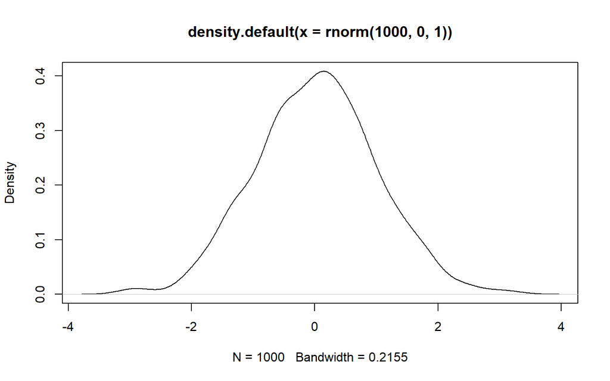

```r
# baz R dizimi ile
plot(density(rnorm(1000, 0, 1)))
```

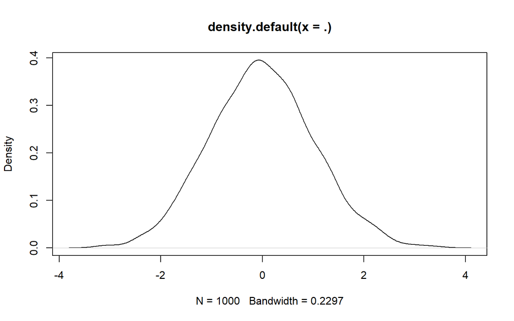

```r
# boru islemcisi ile
rnorm(1000, 0, 1) %>% density() %>% plot()
```

# 5 Veri İşleme İçin `dplyr`

`dplyr` en popüler `tidyverse` paketidir ve veri işleme ve veri yönetimi ile ilgilidir.

## 5.1 Örnek Verinin Okunması

Çalışma için `results` veriseti ile başlayalım. Veriseti, 1872’den 2018’e kadar tüm uluslararası futbol maçlarının sonuçlarını içermektedir.

```r
# verinin okunmasi
df <- read_csv("data/results.csv")
# dataframe'in tibble veri çerçevesine dönüstürülmesi
df <- tbl_df(df)
df
```

```
# A tibble: 39,669 x 9
   date       home_team away_team home_score away_score tournament city  country
   <date>     <chr>     <chr>          <dbl>      <dbl> <chr>      <chr> <chr>
 1 1872-11-30 Scotland  England            0          0 Friendly   Glas~ Scotla~
 2 1873-03-08 England   Scotland           4          2 Friendly   Lond~ England
 3 1874-03-07 Scotland  England            2          1 Friendly   Glas~ Scotla~
 4 1875-03-06 England   Scotland           2          2 Friendly   Lond~ England
 5 1876-03-04 Scotland  England            3          0 Friendly   Glas~ Scotla~
 6 1876-03-25 Scotland  Wales              4          0 Friendly   Glas~ Scotla~
 7 1877-03-03 England   Scotland           1          3 Friendly   Lond~ England
 8 1877-03-05 Wales     Scotland           0          2 Friendly   Wrex~ Wales
 9 1878-03-02 Scotland  England            7          2 Friendly   Glas~ Scotla~
10 1878-03-23 Scotland  Wales              9          0 Friendly   Glas~ Scotla~
# ... with 39,659 more rows, and 1 more variable: neutral <lgl>
```

## 5.2 Fiil Olarak `dplyr` İşlevleri

`dplyr` paketinden en çok kullanılan işlevler:

- `select()` : sütunların seçilmesi
- `mutate()` : var olan değişkenlerin değiştirilmesi, yeni değişkenler yaratılması
- `filter()` : belli kriterlere göre verinin filtrelenmesi
- `summarize()`: belli bir düzeyde verinin özetlenmesi
- `group_by()` : veriyi belli bir değişkene göre gruplama
- `slice()` : belli satırların alınması

Diğer işlevler:

- `count()` : verinin sayılması
- `arrange()` : bir değişkene göre verinin düzenlenmesi, sıralanması
- `distinct()` : bir değişkenin tüm tekil değerlerinin alınması
- `n_distinct()` : bir değişkendeki tekil gözlem sayısı (sadece `summarize` işlevi ile çalışır)
- `n()` : belli bir altgruptaki gözlem sayısı
- `sample_n()` : veri N adet örnek alınması
- `sampsle_frac()`: veriden belli bir yüzdede örnek alınması
- `ungroup()` : gruplanmış bir verinin eski haline getirilmesi
- `glimpse()` : veriyi hızlı bir şekilde önizleme
- `top_n()` : verinin ilk N adet gözleminin getirilmesi

## 5.3 `select` İşlevi: Sütunların Seçilmesi

```r
# baz R
df_old <- df[, c("date", "away_score", "home_score")]
# dplyr
df %>% select(., date, home_team, away_team)
```

```
# A tibble: 39,669 x 3
   date       home_team away_team
   <date>     <chr>     <chr>
 1 1872-11-30 Scotland  England
 2 1873-03-08 England   Scotland
 3 1874-03-07 Scotland  England
 4 1875-03-06 England   Scotland
 5 1876-03-04 Scotland  England
 6 1876-03-25 Scotland  Wales
 7 1877-03-03 England   Scotland
 8 1877-03-05 Wales     Scotland
 9 1878-03-02 Scotland  England
10 1878-03-23 Scotland  Wales
# ... with 39,659 more rows
```

```r
# veya
df %>% select(., 2:3, -5)
```

```
# A tibble: 39,669 x 2
   home_team away_team
   <chr>     <chr>
 1 Scotland  England
 2 England   Scotland
 3 Scotland  England
 4 England   Scotland
 5 Scotland  England
 6 Scotland  Wales
 7 England   Scotland
 8 Wales     Scotland
 9 Scotland  England
10 Scotland  Wales
# ... with 39,659 more rows
```

## 5.4 `filter` İşlevi: Satırların Seçilmesi

```r
conflict_prefer("filter", "dplyr")

# ev sahibi takimin Brezilya oldugu satirlar
df %>% filter(home_team == "Brazil")
```

```
# A tibble: 552 x 9
   date       home_team away_team home_score away_score tournament city  country
   <date>     <chr>     <chr>          <dbl>      <dbl> <chr>      <chr> <chr>
 1 1916-07-08 Brazil    Chile              1          1 Copa Amér~ Buen~ Argent~
 2 1916-07-12 Brazil    Uruguay            1          2 Copa Amér~ Buen~ Argent~
 3 1917-10-12 Brazil    Chile              5          0 Copa Amér~ Mont~ Uruguay
 4 1919-05-11 Brazil    Chile              6          0 Copa Amér~ Rio ~ Brazil
 5 1919-05-18 Brazil    Argentina          3          1 Copa Amér~ Rio ~ Brazil
 6 1919-05-26 Brazil    Uruguay            2          2 Copa Amér~ Rio ~ Brazil
 7 1919-05-29 Brazil    Uruguay            1          0 Copa Amér~ Rio ~ Brazil
 8 1919-06-01 Brazil    Argentina          3          3 Friendly   Rio ~ Brazil
 9 1920-09-18 Brazil    Uruguay            0          6 Copa Amér~ Viña~ Chile
10 1921-10-12 Brazil    Paraguay           3          0 Copa Amér~ Buen~ Argent~
# ... with 542 more rows, and 1 more variable: neutral <lgl>
```

```r
# baz R
df[df$home_team == "Brazil", ]
```

```
# A tibble: 552 x 9
   date       home_team away_team home_score away_score tournament city  country
   <date>     <chr>     <chr>          <dbl>      <dbl> <chr>      <chr> <chr>
 1 1916-07-08 Brazil    Chile              1          1 Copa Amér~ Buen~ Argent~
 2 1916-07-12 Brazil    Uruguay            1          2 Copa Amér~ Buen~ Argent~
 3 1917-10-12 Brazil    Chile              5          0 Copa Amér~ Mont~ Uruguay
 4 1919-05-11 Brazil    Chile              6          0 Copa Amér~ Rio ~ Brazil
 5 1919-05-18 Brazil    Argentina          3          1 Copa Amér~ Rio ~ Brazil
 6 1919-05-26 Brazil    Uruguay            2          2 Copa Amér~ Rio ~ Brazil
 7 1919-05-29 Brazil    Uruguay            1          0 Copa Amér~ Rio ~ Brazil
 8 1919-06-01 Brazil    Argentina          3          3 Friendly   Rio ~ Brazil
 9 1920-09-18 Brazil    Uruguay            0          6 Copa Amér~ Viña~ Chile
10 1921-10-12 Brazil    Paraguay           3          0 Copa Amér~ Buen~ Argent~
# ... with 542 more rows, and 1 more variable: neutral <lgl>
```

```r
df %>% filter(home_team == "Brazil", home_score - away_score > 0) %>% select(date,
    away_team, tournament)
```

```
# A tibble: 395 x 3
   date       away_team tournament
   <date>     <chr>     <chr>
 1 1917-10-12 Chile     Copa América
 2 1919-05-11 Chile     Copa América
 3 1919-05-18 Argentina Copa América
 4 1919-05-29 Uruguay   Copa América
 5 1921-10-12 Paraguay  Copa América
 6 1922-10-15 Argentina Copa América
 7 1922-10-22 Paraguay  Copa América
 8 1922-10-22 Argentina Copa Roca
 9 1922-10-29 Paraguay  Friendly
10 1923-11-22 Paraguay  Friendly
# ... with 385 more rows
```

## 5.5 `mutate` İşlevi: Yeni Değişkenler Oluşturma

```r
# gol farki alani olarak dif, gol farki yüksek ise bunu belirten bir goleada
# alani ekleyip Brezilya takiminin oldugu maçlari filtreleyelim

# burada ifelse islevinin kullanimina dikkat edin: #ifelse(condition, TRUE,
# FALSE)

conflict_prefer("filter", "dplyr")

df %>% mutate(dif = abs(away_score - home_score), goleada = ifelse(dif > 5, "Goleada",
    "Normal  Result")) %>% filter(home_team == "Brazil" | away_team == "Brazil",
    goleada == "Goleada")
```

```
# A tibble: 41 x 11
   date       home_team away_team home_score away_score tournament city  country
   <date>     <chr>     <chr>          <dbl>      <dbl> <chr>      <chr> <chr>
 1 1919-05-11 Brazil    Chile              6          0 Copa Amér~ Rio ~ Brazil
 2 1920-09-18 Brazil    Uruguay            0          6 Copa Amér~ Viña~ Chile
 3 1945-02-21 Brazil    Ecuador            9          2 Copa Amér~ Sant~ Chile
 4 1949-04-03 Brazil    Ecuador            9          1 Copa Amér~ Rio ~ Brazil
 5 1949-04-10 Brazil    Bolivia           10          1 Copa Amér~ São ~ Brazil
 6 1949-04-24 Brazil    Peru               7          1 Copa Amér~ Rio ~ Brazil
 7 1949-05-11 Brazil    Paraguay           7          0 Copa Amér~ Rio ~ Brazil
 8 1950-07-09 Brazil    Sweden             7          1 FIFA Worl~ Rio ~ Brazil
 9 1953-03-01 Bolivia   Brazil             1          8 Copa Amér~ Lima  Peru
10 1956-03-13 Brazil    Costa Ri~          7          1 Pan Ameri~ Mexi~ Mexico
# ... with 31 more rows, and 3 more variables: neutral <lgl>, dif <dbl>,
#   goleada <chr>
```

```r
# baz R
df_g <- df
df_g$dif <- abs(df$home_score - df$away_score)
df_g$goleada <- ifelse(df_g$dif > 5, "Goleada", "NR")
df_g <- df_g[c(df$home_team == "Brazil" | df$away_team == "Brazil") & df_g$goleada ==
    1, c("home_team", "away_score", "goleada", "dif")]
```

## 5.6 `arrange` İşlevi: Verinin Belli Bir Değişkene Göre Sıralanması

```r
# en büyük gol farki kaçtir?
df %>% mutate(dif = abs(away_score - home_score)) %>% arrange(desc(dif)) %>% slice(1)
```

```
# A tibble: 1 x 10
  date       home_team away_team home_score away_score tournament city  country
  <date>     <chr>     <chr>          <dbl>      <dbl> <chr>      <chr> <chr>
1 2001-04-11 Australia American~         31          0 FIFA Worl~ Coff~ Austra~
# ... with 2 more variables: neutral <lgl>, dif <dbl>
```

## 5.7 `slice` İşlevi: Verinin Satırlara Göre Dilimlenmesi

```r
# en büyük gol farkinin oldugu 5 maç
df %>% mutate(dif = abs(away_score - home_score)) %>% arrange(desc(dif)) %>% slice(1:5)  # burada top_n(5) diger bir seçenektir
```

```
# A tibble: 5 x 10
  date       home_team away_team home_score away_score tournament city  country
  <date>     <chr>     <chr>          <dbl>      <dbl> <chr>      <chr> <chr>
1 2001-04-11 Australia American~         31          0 FIFA Worl~ Coff~ Austra~
2 1979-08-30 Fiji      Kiribati          24          0 South Pac~ Naus~ Fiji
3 2001-04-09 Australia Tonga             22          0 FIFA Worl~ Coff~ Austra~
4 2005-03-11 Guam      Korea DPR          0         21 EAFF Cham~ Taip~ Taiwan
5 1987-12-15 American~ Papua Ne~          0         20 South Pac~ Noum~ New Ca~
# ... with 2 more variables: neutral <lgl>, dif <dbl>
```

## 5.8 `group_by` + `summarize` : Gruplar Bazında Özet İstatistikler

İlk aşamada ilgilenilen değişkene göre gruplama yapılır. İkinci aşamada ise yeni istatistiklerle veri özetlenir.

Bazı özet istatistik işlevleri:

- `min(x)` - x vektörünün en küçük değeri.
- `max(x)` - x vektörünün en büyük değeri.
- `mean(x)` - x vektörünün ortalaması.
- `median(x)` - x vektörünün medyanı.
- `quantile(x, p)` - x vektörünün p-inci kantili.
- `sd(x)` - x vektörünün standart sapması.
- `var(x)` - x vektörünün varyansı.
- `IQR(x)` - x vektörünün IQR değeri.
- `diff(range(x))` - x vektörünün genişliği.

```r
# ev sahibi takimlar tarafindan atilan goller için bir veri özeti
df %>% group_by(home_team) %>% summarise(mean_home_gols = mean(home_score, na.rm = TRUE),
    sd_home_gols = sd(home_score), mean_home_gols_op = mean(away_score), count = n()) %>%
    ungroup() %>% top_n(., 10, wt = mean_home_gols)
```

```
# A tibble: 10 x 5
   home_team       mean_home_gols sd_home_gols mean_home_gols_op count
   <chr>                    <dbl>        <dbl>             <dbl> <int>
 1 Cascadia                  4           NA                0         1
 2 Gotland                   3.35         2.96             2.1      20
 3 Guersney                  3.25         2.51             1.04     24
 4 Kárpátalja                3.4          1.14             1.8       5
 5 Micronesia FS             3.5          4.95             9         2
 6 North Vietnam             3.6          3.13             1.8       5
 7 Northern Cyprus           3.70         3.97             0.609    23
 8 Sápmi                     4.12         5.75             1.5      16
 9 Somaliland                3.5          4.95             2.5       2
10 Western Sahara            3.33         1.53             2.33      3
```

Burada `summarize` işlevinin `mutate` ile aynı olmadığına dikkat edin:

```r
df %>% group_by(home_team) %>% mutate(mean_home_gols = mean(home_score, na.rm = TRUE),
    sd_home_gols = sd(home_score), mean_home_gols_op = mean(away_score), count = n()) %>%
    ungroup() %>% select(home_team, mean_home_gols) %>% top_n(., 10, wt = mean_home_gols)
```

```
# A tibble: 16 x 2
   home_team mean_home_gols
   <chr>              <dbl>
 1 Sápmi               4.12
 2 Sápmi               4.12
 3 Sápmi               4.12
 4 Sápmi               4.12
 5 Sápmi               4.12
 6 Sápmi               4.12
 7 Sápmi               4.12
 8 Sápmi               4.12
 9 Sápmi               4.12
10 Sápmi               4.12
11 Sápmi               4.12
12 Sápmi               4.12
13 Sápmi               4.12
14 Sápmi               4.12
15 Sápmi               4.12
16 Sápmi               4.12
```

## 5.9 Diğer Kullanışlı İşlevler

### 5.9.1 `glimpse` : Veri Önizleme

```r
glimpse(df)
```

```
Rows: 39,669
Columns: 9
$ date       <date> 1872-11-30, 1873-03-08, 1874-03-07, 1875-03-06, 1876-03...
$ home_team  <chr> "Scotland", "England", "Scotland", "England", "Scotland"...
$ away_team  <chr> "England", "Scotland", "England", "Scotland", "England",...
$ home_score <dbl> 0, 4, 2, 2, 3, 4, 1, 0, 7, 9, 2, 5, 0, 5, 2, 5, 0, 1, 1,...
$ away_score <dbl> 0, 2, 1, 2, 0, 0, 3, 2, 2, 0, 1, 4, 3, 4, 3, 1, 1, 6, 5,...
$ tournament <chr> "Friendly", "Friendly", "Friendly", "Friendly", "Friendl...
$ city       <chr> "Glasgow", "London", "Glasgow", "London", "Glasgow", "Gl...
$ country    <chr> "Scotland", "England", "Scotland", "England", "Scotland"...
$ neutral    <lgl> FALSE, FALSE, FALSE, FALSE, FALSE, FALSE, FALSE, FALSE, ...
```

### 5.9.2 `count`

```r
# grup bazinda satir sayisi
df %>% count(home_team, tournament) %>% arrange(desc(n))
```

```
# A tibble: 1,710 x 3
   home_team   tournament     n
   <chr>       <chr>      <int>
 1 Germany     Friendly     289
 2 France      Friendly     286
 3 Mexico      Friendly     275
 4 Hungary     Friendly     272
 5 Sweden      Friendly     250
 6 Austria     Friendly     246
 7 Belgium     Friendly     242
 8 Poland      Friendly     241
 9 Netherlands Friendly     239
10 Switzerland Friendly     238
# ... with 1,700 more rows
```

### 5.9.3 Bazı Yardımcı İşlevler

- `starts_with()`: belli bir önek ile başlayan
- `ends_with()`: belli bir son ek ile biten
- `contains()`: belli bir dizgeyi içeren
- `matches()`: düzenli bir ifade ile eşleşen
- `num_range()`: x01, x02, x03 gibi bir sayısal değer aralığı
- `one_of()`: belli karakter vektöründeki değişkenler
- `everything()`: tüm değişkenler

Başka bir veriseti:

```r
new_df <- read_csv("data/battles.csv")
glimpse(new_df)
```

```
Rows: 38
Columns: 25
$ name               <chr> "Battle of the Golden Tooth", "Battle at the Mum...
$ year               <dbl> 298, 298, 298, 298, 298, 298, 298, 299, 299, 299...
$ battle_number      <dbl> 1, 2, 3, 4, 5, 6, 7, 8, 9, 10, 11, 12, 13, 14, 1...
$ attacker_king      <chr> "Joffrey/Tommen Baratheon", "Joffrey/Tommen Bara...
$ defender_king      <chr> "Robb Stark", "Robb Stark", "Robb Stark", "Joffr...
$ attacker_1         <chr> "Lannister", "Lannister", "Lannister", "Stark", ...
$ attacker_2         <chr> NA, NA, NA, NA, "Tully", "Tully", NA, NA, NA, NA...
$ attacker_3         <chr> NA, NA, NA, NA, NA, NA, NA, NA, NA, NA, NA, NA, ...
$ attacker_4         <chr> NA, NA, NA, NA, NA, NA, NA, NA, NA, NA, NA, NA, ...
$ defender_1         <chr> "Tully", "Baratheon", "Tully", "Lannister", "Lan...
$ defender_2         <chr> NA, NA, NA, NA, NA, NA, NA, NA, NA, NA, NA, NA, ...
$ defender_3         <lgl> NA, NA, NA, NA, NA, NA, NA, NA, NA, NA, NA, NA, ...
$ defender_4         <lgl> NA, NA, NA, NA, NA, NA, NA, NA, NA, NA, NA, NA, ...
$ attacker_outcome   <chr> "win", "win", "win", "loss", "win", "win", "win"...
$ battle_type        <chr> "pitched battle", "ambush", "pitched battle", "p...
$ major_death        <dbl> 1, 1, 0, 1, 1, 0, 0, 0, 0, 0, 0, 0, 0, 1, 1, 1, ...
$ major_capture      <dbl> 0, 0, 1, 1, 1, 0, 0, 0, 0, 0, 0, 1, 1, 0, 1, 0, ...
$ attacker_size      <dbl> 15000, NA, 15000, 18000, 1875, 6000, NA, NA, 100...
$ defender_size      <dbl> 4000, 120, 10000, 20000, 6000, 12625, NA, NA, NA...
$ attacker_commander <chr> "Jaime Lannister", "Gregor Clegane", "Jaime Lann...
$ defender_commander <chr> "Clement Piper, Vance", "Beric Dondarrion", "Edm...
$ summer             <dbl> 1, 1, 1, 1, 1, 1, 1, 1, 1, 1, 1, 1, 1, 1, 1, 1, ...
$ location           <chr> "Golden Tooth", "Mummer's Ford", "Riverrun", "Gr...
$ region             <chr> "The Westerlands", "The Riverlands", "The Riverl...
$ note               <chr> NA, NA, NA, NA, NA, NA, NA, NA, NA, "Greyjoy's t...
```

```r
# seçim
new_df %>% select(name, year, contains("king"), starts_with("battle")) %>% glimpse()
```

```
Rows: 38
Columns: 6
$ name          <chr> "Battle of the Golden Tooth", "Battle at the Mummer's...
$ year          <dbl> 298, 298, 298, 298, 298, 298, 298, 299, 299, 299, 299...
$ attacker_king <chr> "Joffrey/Tommen Baratheon", "Joffrey/Tommen Baratheon...
$ defender_king <chr> "Robb Stark", "Robb Stark", "Robb Stark", "Joffrey/To...
$ battle_number <dbl> 1, 2, 3, 4, 5, 6, 7, 8, 9, 10, 11, 12, 13, 14, 15, 16...
$ battle_type   <chr> "pitched battle", "ambush", "pitched battle", "pitche...
```

```r
# yeniden siralama
new_df %>% select(name, year, contains("king"), starts_with("battle"), everything()) %>%
    glimpse()
```

```
Rows: 38
Columns: 25
$ name               <chr> "Battle of the Golden Tooth", "Battle at the Mum...
$ year               <dbl> 298, 298, 298, 298, 298, 298, 298, 299, 299, 299...
$ attacker_king      <chr> "Joffrey/Tommen Baratheon", "Joffrey/Tommen Bara...
$ defender_king      <chr> "Robb Stark", "Robb Stark", "Robb Stark", "Joffr...
$ battle_number      <dbl> 1, 2, 3, 4, 5, 6, 7, 8, 9, 10, 11, 12, 13, 14, 1...
$ battle_type        <chr> "pitched battle", "ambush", "pitched battle", "p...
$ attacker_1         <chr> "Lannister", "Lannister", "Lannister", "Stark", ...
$ attacker_2         <chr> NA, NA, NA, NA, "Tully", "Tully", NA, NA, NA, NA...
$ attacker_3         <chr> NA, NA, NA, NA, NA, NA, NA, NA, NA, NA, NA, NA, ...
$ attacker_4         <chr> NA, NA, NA, NA, NA, NA, NA, NA, NA, NA, NA, NA, ...
$ defender_1         <chr> "Tully", "Baratheon", "Tully", "Lannister", "Lan...
$ defender_2         <chr> NA, NA, NA, NA, NA, NA, NA, NA, NA, NA, NA, NA, ...
$ defender_3         <lgl> NA, NA, NA, NA, NA, NA, NA, NA, NA, NA, NA, NA, ...
$ defender_4         <lgl> NA, NA, NA, NA, NA, NA, NA, NA, NA, NA, NA, NA, ...
$ attacker_outcome   <chr> "win", "win", "win", "loss", "win", "win", "win"...
$ major_death        <dbl> 1, 1, 0, 1, 1, 0, 0, 0, 0, 0, 0, 0, 0, 1, 1, 1, ...
$ major_capture      <dbl> 0, 0, 1, 1, 1, 0, 0, 0, 0, 0, 0, 1, 1, 0, 1, 0, ...
$ attacker_size      <dbl> 15000, NA, 15000, 18000, 1875, 6000, NA, NA, 100...
$ defender_size      <dbl> 4000, 120, 10000, 20000, 6000, 12625, NA, NA, NA...
$ attacker_commander <chr> "Jaime Lannister", "Gregor Clegane", "Jaime Lann...
$ defender_commander <chr> "Clement Piper, Vance", "Beric Dondarrion", "Edm...
$ summer             <dbl> 1, 1, 1, 1, 1, 1, 1, 1, 1, 1, 1, 1, 1, 1, 1, 1, ...
$ location           <chr> "Golden Tooth", "Mummer's Ford", "Riverrun", "Gr...
$ region             <chr> "The Westerlands", "The Riverlands", "The Riverl...
$ note               <chr> NA, NA, NA, NA, NA, NA, NA, NA, NA, "Greyjoy's t...
```

```r
# gerekli olmayan bilginin silinmesi
new_df %>% select(name, year, contains("king"), starts_with("battle"), everything(),
    -matches(c("1$|2$|3$|4$"))) %>% glimpse()
```

```
Rows: 38
Columns: 17
$ name               <chr> "Battle of the Golden Tooth", "Battle at the Mum...
$ year               <dbl> 298, 298, 298, 298, 298, 298, 298, 299, 299, 299...
$ attacker_king      <chr> "Joffrey/Tommen Baratheon", "Joffrey/Tommen Bara...
$ defender_king      <chr> "Robb Stark", "Robb Stark", "Robb Stark", "Joffr...
$ battle_number      <dbl> 1, 2, 3, 4, 5, 6, 7, 8, 9, 10, 11, 12, 13, 14, 1...
$ battle_type        <chr> "pitched battle", "ambush", "pitched battle", "p...
$ attacker_outcome   <chr> "win", "win", "win", "loss", "win", "win", "win"...
$ major_death        <dbl> 1, 1, 0, 1, 1, 0, 0, 0, 0, 0, 0, 0, 0, 1, 1, 1, ...
$ major_capture      <dbl> 0, 0, 1, 1, 1, 0, 0, 0, 0, 0, 0, 1, 1, 0, 1, 0, ...
$ attacker_size      <dbl> 15000, NA, 15000, 18000, 1875, 6000, NA, NA, 100...
$ defender_size      <dbl> 4000, 120, 10000, 20000, 6000, 12625, NA, NA, NA...
$ attacker_commander <chr> "Jaime Lannister", "Gregor Clegane", "Jaime Lann...
$ defender_commander <chr> "Clement Piper, Vance", "Beric Dondarrion", "Edm...
$ summer             <dbl> 1, 1, 1, 1, 1, 1, 1, 1, 1, 1, 1, 1, 1, 1, 1, 1, ...
$ location           <chr> "Golden Tooth", "Mummer's Ford", "Riverrun", "Gr...
$ region             <chr> "The Westerlands", "The Riverlands", "The Riverl...
$ note               <chr> NA, NA, NA, NA, NA, NA, NA, NA, NA, "Greyjoy's t...
```

# 6 `readr` ile Verinin Okunması

Verinin ilk olarak doğru formatta okunması oldukça önemlidir. Bunun için `readr` paketindeki işlevleri kullanmak oldukça fayda sağlar.

Verinin okunması için bazı işleevler:

- `read_csv()` : csv dosyaları
- `read_tsv()` : tsv dosyaları
- `read_delim()`: genel virgülle ayrılmış dosyalar
- `read_fwf()` : sabit aralıklı dosyalar
- `read_table()`: txt dosyaları
- `read_log()` : web log dosyaları

`parse_` işlevi ailesi:

- `parse_logical`
- `parse_integer`
- `parse_factor`
- `parse_character`
- `parse_date`

Bu işlevler, değişkenlerle ilgili tip hatalarını çözmek için oldukça faydalıdır.

```r
# sayisal
x <- c("1", "2", "3")
parse_number(x)
```

```
[1] 1 2 3
```

```r
# karakter
names <- c("kalem", "silgi", "bez", 3)
parse_character(names)
```

```
[1] "kalem" "silgi" "bez"   "3"
```

```r
# tarih
parse_date("30 december 1988", format = "%d %B %y")
```

```
[1] NA
```

```r
parse_date("30 december 1988", format = "%d %B %Y")
```

```
[1] "1988-12-30"
```

```r
# daha da ilginci: hatayi kullanici için döndürür
x <- c("1", "2", "3", "tiago")
parse_number(x)
```

```
[1]  1  2  3 NA
attr(,"problems")
# A tibble: 1 x 4
    row   col expected actual
  <int> <int> <chr>    <chr>
1     4    NA a number tiago
```

```r
# ek olarak
x <- c("10%", "$1000", "10 reais")
parse_number(x)
```

```
[1]   10 1000   10
```

Tüm `parse_*` işlevlerini verisetini okurken `col_*` parametrelerini değiştirerek kullanabiliriz.

```r
cd_df <- read_csv("data/character-deaths.csv")
glimpse(cd_df)
```

```
Rows: 917
Columns: 13
$ name          <chr> "Addam Marbrand", "Aegon Frey (Jinglebell)", "Aegon T...
$ Allegiances   <chr> "Lannister", "None", "House Targaryen", "House Greyjo...
$ Death_y       <chr> "na", "299", NA, "300", NA, NA, "300", "300", NA, NA,...
$ Book_Death    <chr> NA, "3", "na", "5", NA, NA, "4", "5", NA, NA, "2", NA...
$ Death_Chapter <chr> NA, "51", ".", "20", NA, NA, "35", NA, NA, NA, "56", ...
$ Book_Intro    <chr> "56", "49", "5", "20", ",", NA, "21", "59", "11", "0"...
$ Gender        <dbl> 1, 1, 1, 1, 1, 1, 1, 0, 1, 1, 1, 1, 1, 0, 1, 1, 1, 0,...
$ Nobility      <dbl> 1, 1, 1, 1, 1, 1, 1, 1, 1, 0, 0, 0, 1, 0, 1, 0, 0, 1,...
$ GoT           <dbl> 1, 0, 0, 0, 0, 0, 1, 1, 0, 0, 0, 1, 0, 0, 1, 1, 0, 0,...
$ CoK           <dbl> 1, 0, 0, 0, 0, 1, 0, 1, 1, 0, 1, 1, 1, 1, 0, 0, 1, 0,...
$ SoS           <dbl> 1, 1, 0, 0, 1, 1, 1, 1, 0, 1, 0, 1, 1, 0, 0, 0, 0, 1,...
$ FfC           <dbl> 1, 0, 0, 0, 0, 0, 1, 0, 1, 0, 0, 0, 0, 0, 1, 0, 0, 1,...
$ DwD           <dbl> 0, 0, 1, 1, 0, 0, 0, 1, 0, 0, 0, 1, 1, 0, 0, 0, 0, 0,...
```

Bazı sayısal değerler bu haliyle karakter tipinde geliyor. Bunu düzeltelim:

```r
cd_df <- read_csv("data/character-deaths.csv", col_types = cols(Death_y = col_number(),
    Book_Death = col_number(), Death_Chapter = col_number(), Book_Intro = col_number()))
glimpse(cd_df)
```

```
Rows: 917
Columns: 13
$ name          <chr> "Addam Marbrand", "Aegon Frey (Jinglebell)", "Aegon T...
$ Allegiances   <chr> "Lannister", "None", "House Targaryen", "House Greyjo...
$ Death_y       <dbl> NA, 299, NA, 300, NA, NA, 300, 300, NA, NA, 299, NA, ...
$ Book_Death    <dbl> NA, 3, NA, 5, NA, NA, 4, 5, NA, NA, 2, NA, 5, NA, NA,...
$ Death_Chapter <dbl> NA, 51, NA, 20, NA, NA, 35, NA, NA, NA, 56, NA, 4, NA...
$ Book_Intro    <dbl> 56, 49, 5, 20, NA, NA, 21, 59, 11, 0, 50, 54, 18, 15,...
$ Gender        <dbl> 1, 1, 1, 1, 1, 1, 1, 0, 1, 1, 1, 1, 1, 0, 1, 1, 1, 0,...
$ Nobility      <dbl> 1, 1, 1, 1, 1, 1, 1, 1, 1, 0, 0, 0, 1, 0, 1, 0, 0, 1,...
$ GoT           <dbl> 1, 0, 0, 0, 0, 0, 1, 1, 0, 0, 0, 1, 0, 0, 1, 1, 0, 0,...
$ CoK           <dbl> 1, 0, 0, 0, 0, 1, 0, 1, 1, 0, 1, 1, 1, 1, 0, 0, 1, 0,...
$ SoS           <dbl> 1, 1, 0, 0, 1, 1, 1, 1, 0, 1, 0, 1, 1, 0, 0, 0, 0, 1,...
$ FfC           <dbl> 1, 0, 0, 0, 0, 0, 1, 0, 1, 0, 0, 0, 0, 0, 1, 0, 0, 1,...
$ DwD           <dbl> 0, 0, 1, 1, 0, 0, 0, 1, 0, 0, 0, 1, 1, 0, 0, 0, 0, 0,...
```

Sorun var mı kontrol edelim:

```r
problems(cd_df)
```

```
# A tibble: 4 x 5
    row col           expected actual file
  <int> <chr>         <chr>    <chr>  <chr>
1     1 Death_y       a number na     'data/character-deaths.csv'
2     3 Book_Death    a number na     'data/character-deaths.csv'
3     3 Death_Chapter a number .      'data/character-deaths.csv'
4     5 Book_Intro    a number ,      'data/character-deaths.csv'
```

Uygun bir çözüm:

```r
cd_df <- read_csv("data/character-deaths.csv", col_types = cols(Death_y = col_number(),
    Book_Death = col_number(), Death_Chapter = col_number(), Book_Intro = col_number()),
    na = c("", "NA", "na", ".", ","))
glimpse(cd_df)
```

```
Rows: 917
Columns: 13
$ name          <chr> "Addam Marbrand", "Aegon Frey (Jinglebell)", "Aegon T...
$ Allegiances   <chr> "Lannister", "None", "House Targaryen", "House Greyjo...
$ Death_y       <dbl> NA, 299, NA, 300, NA, NA, 300, 300, NA, NA, 299, NA, ...
$ Book_Death    <dbl> NA, 3, NA, 5, NA, NA, 4, 5, NA, NA, 2, NA, 5, NA, NA,...
$ Death_Chapter <dbl> NA, 51, NA, 20, NA, NA, 35, NA, NA, NA, 56, NA, 4, NA...
$ Book_Intro    <dbl> 56, 49, 5, 20, NA, NA, 21, 59, 11, 0, 50, 54, 18, 15,...
$ Gender        <dbl> 1, 1, 1, 1, 1, 1, 1, 0, 1, 1, 1, 1, 1, 0, 1, 1, 1, 0,...
$ Nobility      <dbl> 1, 1, 1, 1, 1, 1, 1, 1, 1, 0, 0, 0, 1, 0, 1, 0, 0, 1,...
$ GoT           <dbl> 1, 0, 0, 0, 0, 0, 1, 1, 0, 0, 0, 1, 0, 0, 1, 1, 0, 0,...
$ CoK           <dbl> 1, 0, 0, 0, 0, 1, 0, 1, 1, 0, 1, 1, 1, 1, 0, 0, 1, 0,...
$ SoS           <dbl> 1, 1, 0, 0, 1, 1, 1, 1, 0, 1, 0, 1, 1, 0, 0, 0, 0, 1,...
$ FfC           <dbl> 1, 0, 0, 0, 0, 0, 1, 0, 1, 0, 0, 0, 0, 0, 1, 0, 0, 1,...
$ DwD           <dbl> 0, 0, 1, 1, 0, 0, 0, 1, 0, 0, 0, 1, 1, 0, 0, 0, 0, 0,...
```

# 7 `tidyR` ile Veri Düzenleme

Geniş boyutlu veriler için `düzenli` kelimesi oldukça sihirli bir kavramdır. Bir verinin aşağıdaki özellikleri sağlıyorsa düzenli olduğu söylenebilir:

- Her değişken kendi sütununda yer alıyorsa.
- Her gözlem kendi satırında yer alıyorsa.

**Düzensiz bir veri örneği:**

| date | home_team | away_team | Atlantic Cup | Brazil Independence Cup | Confederations Cup | Copa América | Copa Bernardo O’Higgins | Copa Oswaldo Cruz | Copa Rio Branco | Copa Roca | FIFA World Cup | FIFA World Cup qualification | Friendly | Gold Cup | Mundialito | Pan American Championship | USA Cup |
| --- | --- | --- | --- | --- | --- | --- | --- | --- | --- | --- | --- | --- | --- | --- | --- | --- | --- |
| 1916-07-08 | Brazil | Chile | NA | NA | NA | 0 | NA | NA | NA | NA | NA | NA | NA | NA | NA | NA | NA |
| 1916-07-12 | Brazil | Uruguay | NA | NA | NA | -1 | NA | NA | NA | NA | NA | NA | NA | NA | NA | NA | NA |
| 1917-10-12 | Brazil | Chile | NA | NA | NA | 5 | NA | NA | NA | NA | NA | NA | NA | NA | NA | NA | NA |
| 1919-05-11 | Brazil | Chile | NA | NA | NA | 6 | NA | NA | NA | NA | NA | NA | NA | NA | NA | NA | NA |
| 1919-05-18 | Brazil | Argentina | NA | NA | NA | 2 | NA | NA | NA | NA | NA | NA | NA | NA | NA | NA | NA |
| 1919-05-26 | Brazil | Uruguay | NA | NA | NA | 0 | NA | NA | NA | NA | NA | NA | NA | NA | NA | NA | NA |
| 1919-05-29 | Brazil | Uruguay | NA | NA | NA | 1 | NA | NA | NA | NA | NA | NA | NA | NA | NA | NA | NA |
| 1919-06-01 | Brazil | Argentina | NA | NA | NA | NA | NA | NA | NA | NA | NA | NA | 0 | NA | NA | NA | NA |
| 1920-09-18 | Brazil | Uruguay | NA | NA | NA | -6 | NA | NA | NA | NA | NA | NA | NA | NA | NA | NA | NA |
| 1921-10-12 | Brazil | Paraguay | NA | NA | NA | 3 | NA | NA | NA | NA | NA | NA | NA | NA | NA | NA | NA |
| 1921-10-23 | Brazil | Uruguay | NA | NA | NA | -1 | NA | NA | NA | NA | NA | NA | NA | NA | NA | NA | NA |
| 1922-09-17 | Brazil | Chile | NA | NA | NA | 0 | NA | NA | NA | NA | NA | NA | NA | NA | NA | NA | NA |
| 1922-09-24 | Brazil | Paraguay | NA | NA | NA | 0 | NA | NA | NA | NA | NA | NA | NA | NA | NA | NA | NA |
| 1922-10-01 | Brazil | Uruguay | NA | NA | NA | 0 | NA | NA | NA | NA | NA | NA | NA | NA | NA | NA | NA |
| 1922-10-15 | Brazil | Argentina | NA | NA | NA | 2 | NA | NA | NA | NA | NA | NA | NA | NA | NA | NA | NA |
| 1922-10-22 | Brazil | Argentina | NA | NA | NA | NA | NA | NA | NA | 1 | NA | NA | NA | NA | NA | NA | NA |
| 1922-10-22 | Brazil | Paraguay | NA | NA | NA | 3 | NA | NA | NA | NA | NA | NA | NA | NA | NA | NA | NA |
| 1922-10-29 | Brazil | Paraguay | NA | NA | NA | NA | NA | NA | NA | NA | NA | NA | 2 | NA | NA | NA | NA |
| 1923-11-11 | Brazil | Paraguay | NA | NA | NA | -1 | NA | NA | NA | NA | NA | NA | NA | NA | NA | NA | NA |
| 1923-11-22 | Brazil | Paraguay | NA | NA | NA | NA | NA | NA | NA | NA | NA | NA | 2 | NA | NA | NA | NA |
| 1925-12-06 | Brazil | Paraguay | NA | NA | NA | 3 | NA | NA | NA | NA | NA | NA | NA | NA | NA | NA | NA |
| 1925-12-17 | Brazil | Paraguay | NA | NA | NA | 2 | NA | NA | NA | NA | NA | NA | NA | NA | NA | NA | NA |
| 1930-07-14 | Brazil | Yugoslavia | NA | NA | NA | NA | NA | NA | NA | NA | -1 | NA | NA | NA | NA | NA | NA |
| 1930-08-01 | Brazil | France | NA | NA | NA | NA | NA | NA | NA | NA | NA | NA | 1 | NA | NA | NA | NA |
| 1930-08-10 | Brazil | Yugoslavia | NA | NA | NA | NA | NA | NA | NA | NA | NA | NA | 3 | NA | NA | NA | NA |
| 1930-08-17 | Brazil | USA | NA | NA | NA | NA | NA | NA | NA | NA | NA | NA | 1 | NA | NA | NA | NA |
| 1931-09-06 | Brazil | Uruguay | NA | NA | NA | NA | NA | NA | 2 | NA | NA | NA | NA | NA | NA | NA | NA |
| 1934-05-27 | Brazil | Spain | NA | NA | NA | NA | NA | NA | NA | NA | -2 | NA | NA | NA | NA | NA | NA |
| 1936-12-27 | Brazil | Peru | NA | NA | NA | 1 | NA | NA | NA | NA | NA | NA | NA | NA | NA | NA | NA |
| 1937-01-03 | Brazil | Chile | NA | NA | NA | 2 | NA | NA | NA | NA | NA | NA | NA | NA | NA | NA | NA |

[output cut: 522 more lines]

**Düzenli bir veri örneği:**

| date | home_team | away_team | home_score | away_score | tournament | city | country | neutral |
| --- | --- | --- | --- | --- | --- | --- | --- | --- |
| 1872-11-30 | Scotland | England | 0 | 0 | Friendly | Glasgow | Scotland | FALSE |
| 1873-03-08 | England | Scotland | 4 | 2 | Friendly | London | England | FALSE |
| 1874-03-07 | Scotland | England | 2 | 1 | Friendly | Glasgow | Scotland | FALSE |
| 1875-03-06 | England | Scotland | 2 | 2 | Friendly | London | England | FALSE |
| 1876-03-04 | Scotland | England | 3 | 0 | Friendly | Glasgow | Scotland | FALSE |
| 1876-03-25 | Scotland | Wales | 4 | 0 | Friendly | Glasgow | Scotland | FALSE |
| 1877-03-03 | England | Scotland | 1 | 3 | Friendly | London | England | FALSE |
| 1877-03-05 | Wales | Scotland | 0 | 2 | Friendly | Wrexham | Wales | FALSE |
| 1878-03-02 | Scotland | England | 7 | 2 | Friendly | Glasgow | Scotland | FALSE |
| 1878-03-23 | Scotland | Wales | 9 | 0 | Friendly | Glasgow | Scotland | FALSE |

## 7.1 `gather` İşlevi

Birden çok sütunu iki sütuna daraltır. Verilerinizi yeniden şekillendirmek bu anlama gelir.

`gather(data, key="my_key", value="values_of_each_col", ...="col_you_have_want_to_distribute")`

```r
df_untidy %>% gather(key = "key", value = "value", 4:18)
```

```
# A tibble: 8,280 x 5
   date       home_team away_team key          value
   <date>     <chr>     <chr>     <chr>        <dbl>
 1 1916-07-08 Brazil    Chile     Atlantic Cup    NA
 2 1916-07-12 Brazil    Uruguay   Atlantic Cup    NA
 3 1917-10-12 Brazil    Chile     Atlantic Cup    NA
 4 1919-05-11 Brazil    Chile     Atlantic Cup    NA
 5 1919-05-18 Brazil    Argentina Atlantic Cup    NA
 6 1919-05-26 Brazil    Uruguay   Atlantic Cup    NA
 7 1919-05-29 Brazil    Uruguay   Atlantic Cup    NA
 8 1919-06-01 Brazil    Argentina Atlantic Cup    NA
 9 1920-09-18 Brazil    Uruguay   Atlantic Cup    NA
10 1921-10-12 Brazil    Paraguay  Atlantic Cup    NA
# ... with 8,270 more rows
```

`Na` sorununun çözümü:

```r
df_untidy %>% gather(key = "key", value = "value", 4:18, na.rm = TRUE)
```

```
# A tibble: 552 x 5
   date       home_team away_team      key                     value
   <date>     <chr>     <chr>          <chr>                   <dbl>
 1 1956-06-24 Brazil    Uruguay        Atlantic Cup                2
 2 1960-07-12 Brazil    Argentina      Atlantic Cup                4
 3 1972-06-28 Brazil    Czechoslovakia Brazil Independence Cup     0
 4 1972-07-02 Brazil    Yugoslavia     Brazil Independence Cup     3
 5 1972-07-05 Brazil    Scotland       Brazil Independence Cup     1
 6 1972-07-09 Brazil    Portugal       Brazil Independence Cup     1
 7 1997-12-16 Brazil    Mexico         Confederations Cup          1
 8 1997-12-19 Brazil    Czech Republic Confederations Cup          2
 9 1997-12-21 Brazil    Australia      Confederations Cup          6
10 1999-07-24 Brazil    Germany        Confederations Cup          4
# ... with 542 more rows
```

Görselleştirme:

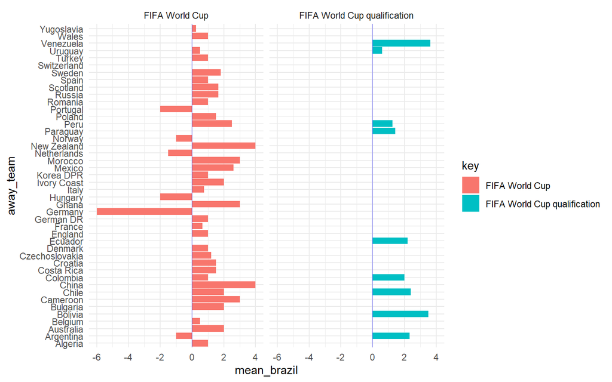

```r
df_untidy %>% select(1:3, contains("FIFA")) %>% gather(key = "key", value = "value",
    4:5, factor_key = TRUE, na.rm = TRUE) %>% group_by(key, away_team) %>% summarise(mean_brazil = mean(value)) %>%
    ggplot(., aes(y = mean_brazil, x = away_team, group = away_team, fill = key)) +
    geom_col(position = "dodge") + coord_flip() + geom_hline(yintercept = 0, alpha = 0.3,
    color = "blue") + facet_wrap(~key) + theme_minimal()
```

## 7.2 `seperate` İşlevi

`separate(data, col="one_you_want_to_separate", into="division", sep="regular_expression")`

```r
df_untidy %>% separate(col = date, into = c("year", "month", "day"))
```

```
# A tibble: 552 x 20
   year  month day   home_team away_team `Atlantic Cup` `Brazil Indepen~
   <chr> <chr> <chr> <chr>     <chr>              <dbl>            <dbl>
 1 1916  07    08    Brazil    Chile                 NA               NA
 2 1916  07    12    Brazil    Uruguay               NA               NA
 3 1917  10    12    Brazil    Chile                 NA               NA
 4 1919  05    11    Brazil    Chile                 NA               NA
 5 1919  05    18    Brazil    Argentina             NA               NA
 6 1919  05    26    Brazil    Uruguay               NA               NA
 7 1919  05    29    Brazil    Uruguay               NA               NA
 8 1919  06    01    Brazil    Argentina             NA               NA
 9 1920  09    18    Brazil    Uruguay               NA               NA
10 1921  10    12    Brazil    Paraguay              NA               NA
# ... with 542 more rows, and 13 more variables: `Confederations Cup` <dbl>,
#   `Copa América` <dbl>, `Copa Bernardo O'Higgins` <dbl>, `Copa Oswaldo
#   Cruz` <dbl>, `Copa Rio Branco` <dbl>, `Copa Roca` <dbl>, `FIFA World
#   Cup` <dbl>, `FIFA World Cup qualification` <dbl>, Friendly <dbl>, `Gold
#   Cup` <dbl>, Mundialito <dbl>, `Pan American Championship` <dbl>, `USA
#   Cup` <dbl>
```

## 7.3 `spread` İşlevi

```r
conflict_prefer("filter", "dplyr")

# turnuva isimlerinin sütunlara alinmasi
df %>% select(1:5, tournament) %>% filter(home_team == "Brazil") %>% mutate(diff = home_score -
    away_score) %>% spread(key = tournament, value = diff) %>% dplyr::select(-contains("score"))
```

```
# A tibble: 552 x 18
   date       home_team away_team `Atlantic Cup` `Brazil Indepen~
   <date>     <chr>     <chr>              <dbl>            <dbl>
 1 1916-07-08 Brazil    Chile                 NA               NA
 2 1916-07-12 Brazil    Uruguay               NA               NA
 3 1917-10-12 Brazil    Chile                 NA               NA
 4 1919-05-11 Brazil    Chile                 NA               NA
 5 1919-05-18 Brazil    Argentina             NA               NA
 6 1919-05-26 Brazil    Uruguay               NA               NA
 7 1919-05-29 Brazil    Uruguay               NA               NA
 8 1919-06-01 Brazil    Argentina             NA               NA
 9 1920-09-18 Brazil    Uruguay               NA               NA
10 1921-10-12 Brazil    Paraguay              NA               NA
# ... with 542 more rows, and 13 more variables: `Confederations Cup` <dbl>,
#   `Copa América` <dbl>, `Copa Bernardo O'Higgins` <dbl>, `Copa Oswaldo
#   Cruz` <dbl>, `Copa Rio Branco` <dbl>, `Copa Roca` <dbl>, `FIFA World
#   Cup` <dbl>, `FIFA World Cup qualification` <dbl>, Friendly <dbl>, `Gold
#   Cup` <dbl>, Mundialito <dbl>, `Pan American Championship` <dbl>, `USA
#   Cup` <dbl>
```

# 8 Veri İşleme için Diğer İşlev ve Paketler

- `case_when()`: `if else` ifadesi yerine kullanılabilir
- `fct_relevel()` : `factor` değişkenlerle kullanılabilir
- `ludibrate` : tarih değişkenleriyle çalışabilecek paket
- `stringr` : dizgelerle çalışabilecek paket